# simulation_for_linear_mixed_model

Xiujuan Wen

2022-07-25

# 1 假定的心理学实验设计

```r
if (!require(tidyverse)) {library(tidyverse)}
if (!require(faux)) {library(faux)}
```

[output not shown]

```r
if (!require(brms)) {library(brms)}
```

[output not shown]

```r
if (!require(bayesplot)) {library(bayesplot)}
```

[output not shown]

我们假定抑郁症患者组有30人，健康对照组有30人。开始之前我们先设置一些假定的参数，以便后续的模型拟合结果对照假定的参数。在起始阶段先设置固定效应，将图片的类型编码(contrast-coded)成-0.5和0.5(负性类型图片编码成-0.5，正性图片编码成0.5)。

```r
#生成假定实验的条件的数据矩阵
data <- add_random(subj = 60) %>%
  add_within("subj", type_of_picture = c("negative","positive")) %>%
  add_between("subj",Groups = c("depression", "control")) %>%
  add_contrast("type_of_picture", "anova", add_cols = TRUE,colnames  = "type") %>%
  add_contrast("Groups", "anova", add_cols = TRUE,colnames = "Group")
```

接着设置固定效应值，并生成固定效应的总值。

```r
subj_n = 60   # 被试数,抑郁患者组30人，健康控制组30人
b0 = 2.5     # 截距
b1 = 4.2     # 图片类型的固定效应
b2 = 4.5       # 组别的固定效应
b3 = 2.4     # 图片类型与组别的交互效应
fixed_true=c(b0,b1,b2,b3)
```

设置随机效应，并生成随机效应的总值。

```r
u0s= 0.01      # 被试的随机截距值
u1s=0.01       # 被试的随机斜率值
u2s=0.03      # 组别的随机截距值
u3s=0.01      # 组别的随机斜率值
u_sd_subj_true=c(u0s,u1s)
u_sd_Group_true=c(u2s,u3s)
data <- data %>%
  # 添加关于被试的随机截距和随机斜率
  add_ranef(c("subj","type"), u0s, u1s) %>%
  # 添加关于被试的组别的随机截距和随机斜率
  add_ranef(c("Group","type"), u2s, u3s) %>%
  # 添加观察值的误差项
  add_ranef(sigma = 0.1)
```

最后根据设置的固定效应和随机效应参数值，生成因变量。

```r
data <-data %>%
  mutate(LPP = b0 +(b1+u0s+u2s)* type + b2 * Group + b3*type*Group+u0s+u3s+ sigma)
head(data,10) #查看生成的数据矩阵
```

```
## # A tibble: 10 x 11
##    subj  type_o~1 Groups  type Group     X1.x     X2.x    X1.y     X2.y    sigma
##    <chr> <fct>    <fct>  <dbl> <dbl>    <dbl>    <dbl>   <dbl>    <dbl>    <dbl>
##  1 s01   negative depre~  -0.5  -0.5  1.11e-2 -3.86e-4 -0.0201 -0.0165  -0.0820
##  2 s01   positive depre~   0.5  -0.5  1.06e-2  2.47e-3  0.0148 -0.00212  0.00984
##  3 s02   negative contr~  -0.5   0.5 -5.47e-3 -1.52e-2  0.0404  0.00248 -0.150
##  4 s02   positive contr~   0.5   0.5 -5.36e-3  4.01e-3 -0.0129 -0.00810 -0.0334
##  5 s03   negative depre~  -0.5  -0.5  4.57e-3  6.44e-5 -0.0201 -0.0165   0.0299
##  6 s03   positive depre~   0.5  -0.5 -7.12e-3 -8.93e-3  0.0148 -0.00212  0.0783
##  7 s04   negative contr~  -0.5   0.5  2.76e-4  3.51e-3  0.0404  0.00248 -0.128
##  8 s04   positive contr~   0.5   0.5  1.06e-2  5.87e-4 -0.0129 -0.00810  0.100
##  9 s05   negative depre~  -0.5  -0.5  1.50e-2 -9.28e-3 -0.0201 -0.0165  -0.0891
## 10 s05   positive depre~   0.5  -0.5 -9.90e-3 -1.66e-2  0.0148 -0.00212  0.149
## # ... with 1 more variable: LPP <dbl>, and abbreviated variable name
## #   1: type_of_picture
## # i Use `colnames()` to see all variable names
```

# 2 数据分析

为了更好地理解贝叶斯混合线性模型，首先我们建立只有固定效应的模型。这里的实验数据的先验将采用brms包自带的默认先验设置。如果不是特别清楚data参数后面的参数设置，可以选用默认设置，示例代码拟合的是高斯模型。summary可以帮助我们展示模型拟合后的参数情况。plot可以显示模型拟合后的参数的分布情况以及mcmc的抽样情况。在模型拟合的数据中如果Rhat>1.01说明模型的收敛情况并不理想，Rhat<=1.01说明模型的收敛情况较好。

```r
model_1 <- brm(LPP ~ Group + type, data = data,family="gaussian",cores = 4,chains = 4,warmup =500,iter = 1000)
summary(model_1)
```

```
##  Family: gaussian
##   Links: mu = identity; sigma = identity
## Formula: LPP ~ Group + type
##    Data: data (Number of observations: 120)
##   Draws: 4 chains, each with iter = 1000; warmup = 500; thin = 1;
##          total post-warmup draws = 2000
##
## Population-Level Effects:
##           Estimate Est.Error l-95% CI u-95% CI Rhat Bulk_ESS Tail_ESS
## Intercept     2.51      0.06     2.40     2.62 1.00     2112     1520
## Group         4.47      0.11     4.26     4.69 1.00     2607     1483
## type          4.26      0.11     4.03     4.48 1.01     2107     1296
##
## Family Specific Parameters:
##       Estimate Est.Error l-95% CI u-95% CI Rhat Bulk_ESS Tail_ESS
## sigma     0.61      0.04     0.54     0.69 1.00     2247     1567
##
## Draws were sampled using sampling(NUTS). For each parameter, Bulk_ESS
## and Tail_ESS are effective sample size measures, and Rhat is the potential
## scale reduction factor on split chains (at convergence, Rhat = 1).
```

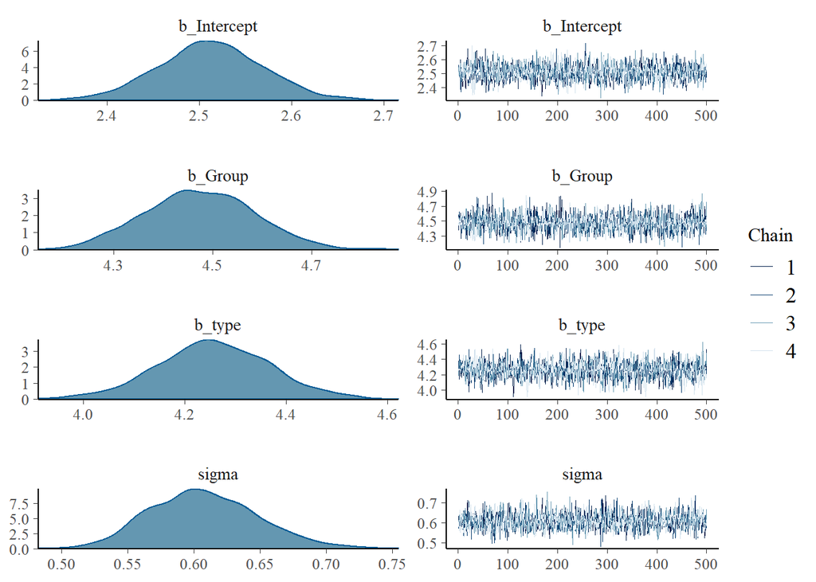

```r
plot(model_1)
```

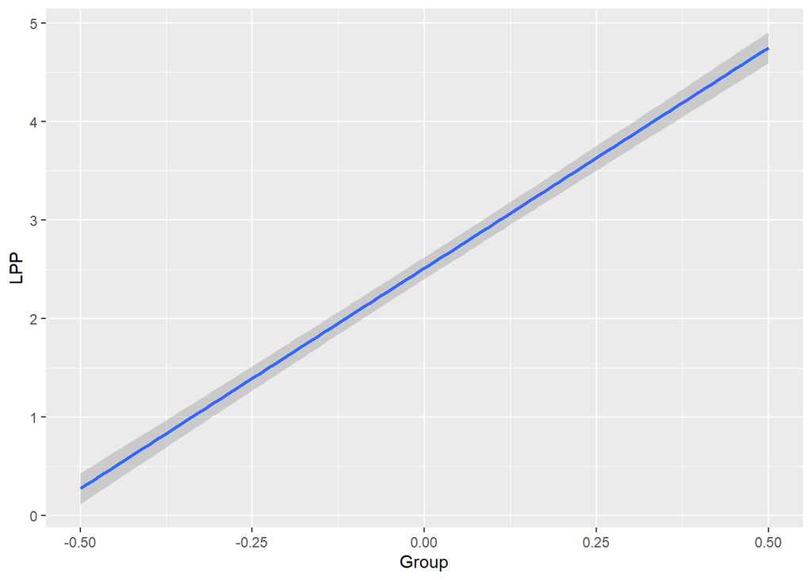

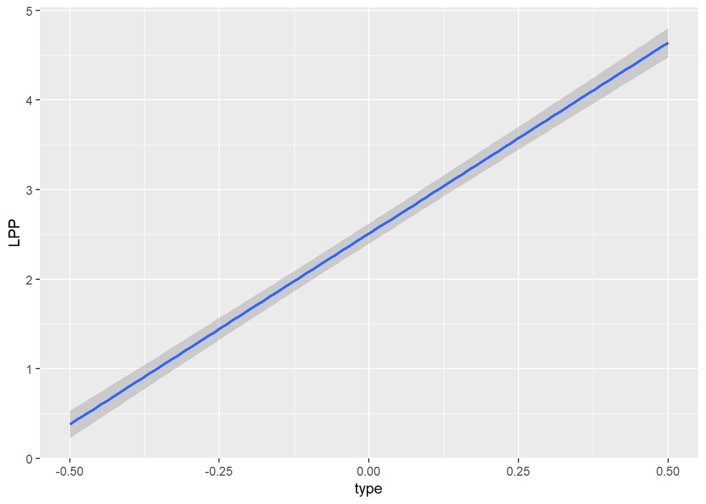

```r
conditional_effects(model_1)
```

以上的代码只是加入了组别和图片类型的变量，如果我们想更好地了解这两个因素的交互效应可以采用下面的代码。

```r
model_2 <- brm(LPP ~ Group * type, data = data,family="gaussian",cores = 4,chains = 4,warmup =500,iter = 1000)
summary(model_2)
```

```
##  Family: gaussian
##   Links: mu = identity; sigma = identity
## Formula: LPP ~ Group * type
##    Data: data (Number of observations: 120)
##   Draws: 4 chains, each with iter = 1000; warmup = 500; thin = 1;
##          total post-warmup draws = 2000
##
## Population-Level Effects:
##            Estimate Est.Error l-95% CI u-95% CI Rhat Bulk_ESS Tail_ESS
## Intercept      2.51      0.01     2.49     2.54 1.00     2267     1365
## Group          4.48      0.02     4.44     4.51 1.00     2513     1568
## type           4.26      0.02     4.22     4.29 1.00     2153     1350
## Group:type     2.34      0.04     2.26     2.42 1.00     2282     1523
##
## Family Specific Parameters:
##       Estimate Est.Error l-95% CI u-95% CI Rhat Bulk_ESS Tail_ESS
## sigma     0.11      0.01     0.10     0.12 1.00     1953     1443
##
## Draws were sampled using sampling(NUTS). For each parameter, Bulk_ESS
## and Tail_ESS are effective sample size measures, and Rhat is the potential
## scale reduction factor on split chains (at convergence, Rhat = 1).
```

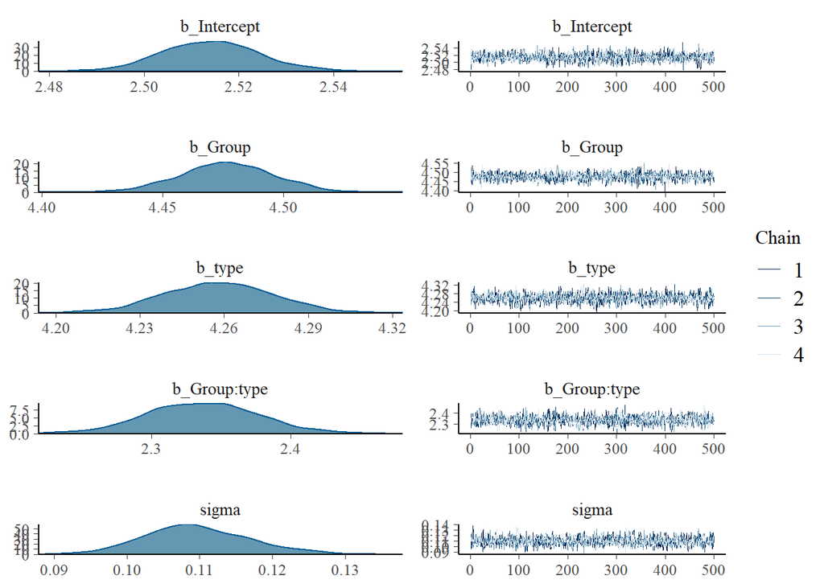

```r
plot(model_2)
```

紧接着接下来在后面的模型中加入一些随机截距。

```r
model_3 <- brm(LPP ~ Group * type +(1|subj)+(1+Group), data = data,family="gaussian",cores = 4,chains = 4,warmup =500,iter = 1000)
summary(model_3)
```

```
##  Family: gaussian
##   Links: mu = identity; sigma = identity
## Formula: LPP ~ Group * type + (1 | subj) + (1 + Group)
##    Data: data (Number of observations: 120)
##   Draws: 4 chains, each with iter = 1000; warmup = 500; thin = 1;
##          total post-warmup draws = 2000
##
## Group-Level Effects:
## ~subj (Number of levels: 60)
##               Estimate Est.Error l-95% CI u-95% CI Rhat Bulk_ESS Tail_ESS
## sd(Intercept)     0.04      0.02     0.00     0.07 1.01      306      514
##
## Population-Level Effects:
##            Estimate Est.Error l-95% CI u-95% CI Rhat Bulk_ESS Tail_ESS
## Intercept      2.51      0.01     2.49     2.54 1.00     1357      864
## Group          4.48      0.02     4.44     4.52 1.00     1646     1189
## type           4.26      0.02     4.22     4.29 1.00     2108      970
## Group:type     2.34      0.04     2.27     2.41 1.00     1968     1351
##
## Family Specific Parameters:
##       Estimate Est.Error l-95% CI u-95% CI Rhat Bulk_ESS Tail_ESS
## sigma     0.10      0.01     0.09     0.12 1.01      640      879
##
## Draws were sampled using sampling(NUTS). For each parameter, Bulk_ESS
## and Tail_ESS are effective sample size measures, and Rhat is the potential
## scale reduction factor on split chains (at convergence, Rhat = 1).
```

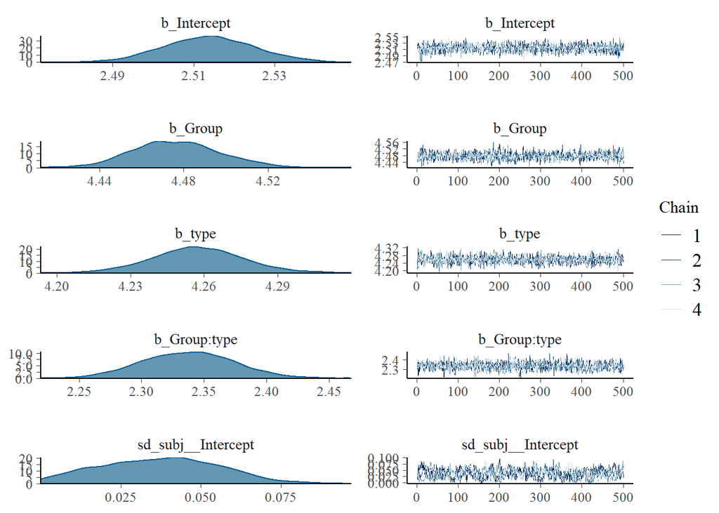

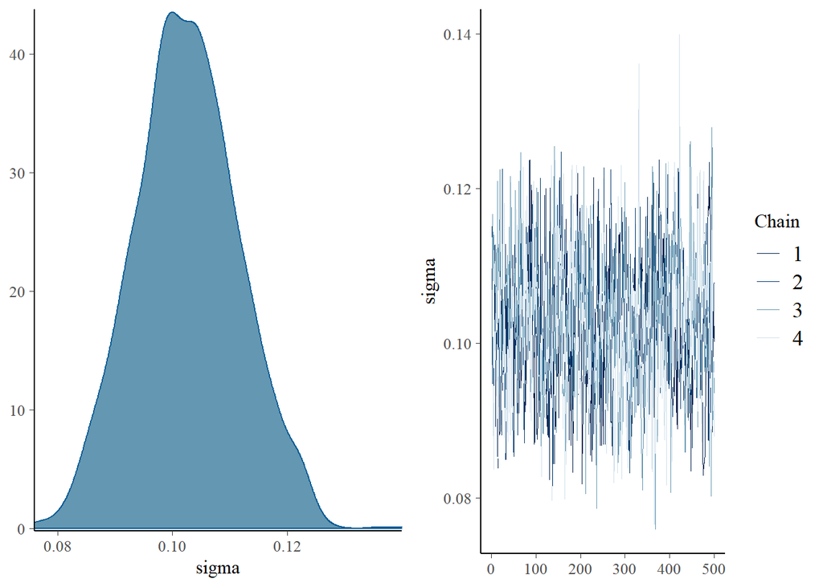

```r
plot(model_3)
```

在前面的代码基础之上加上随机斜率。探究在不同被试，不同组别下图片对LPP波幅的影响。

```r
model_4 <- brm(LPP ~ Group * type +(1+type|Group)+(1+type|subj), data = data,family="gaussian",cores = 4,chains = 4,warmup =500,iter = 1000)
summary(model_4)
```

```
##  Family: gaussian
##   Links: mu = identity; sigma = identity
## Formula: LPP ~ Group * type + (1 + type | Group) + (1 + type | subj)
##    Data: data (Number of observations: 120)
##   Draws: 4 chains, each with iter = 1000; warmup = 500; thin = 1;
##          total post-warmup draws = 2000
##
## Group-Level Effects:
## ~Group (Number of levels: 2)
##                     Estimate Est.Error l-95% CI u-95% CI Rhat Bulk_ESS Tail_ESS
## sd(Intercept)           1.62      1.30     0.06     4.85 1.01      313      367
## sd(type)                2.24      1.92     0.12     7.22 1.02      270      327
## cor(Intercept,type)    -0.03      0.58    -0.94     0.95 1.00     1021     1235
##
## ~subj (Number of levels: 60)
##                     Estimate Est.Error l-95% CI u-95% CI Rhat Bulk_ESS Tail_ESS
## sd(Intercept)           0.04      0.02     0.01     0.08 1.03       99      303
## sd(type)                0.04      0.03     0.00     0.11 1.02      103      225
## cor(Intercept,type)     0.22      0.49    -0.83     0.95 1.01      454      677
##
## Population-Level Effects:
##            Estimate Est.Error l-95% CI u-95% CI Rhat Bulk_ESS Tail_ESS
## Intercept      2.39      1.01     0.06     4.49 1.01      381      375
## Group          4.67      2.45    -0.05    10.19 1.01      365      256
## type           4.41      1.90     0.98     8.87 1.02      330      161
## Group:type     2.10      3.64    -7.00     9.21 1.02      329      182
##
## Family Specific Parameters:
##       Estimate Est.Error l-95% CI u-95% CI Rhat Bulk_ESS Tail_ESS
## sigma     0.10      0.01     0.07     0.12 1.03       88      230
##
## Draws were sampled using sampling(NUTS). For each parameter, Bulk_ESS
## and Tail_ESS are effective sample size measures, and Rhat is the potential
## scale reduction factor on split chains (at convergence, Rhat = 1).
```

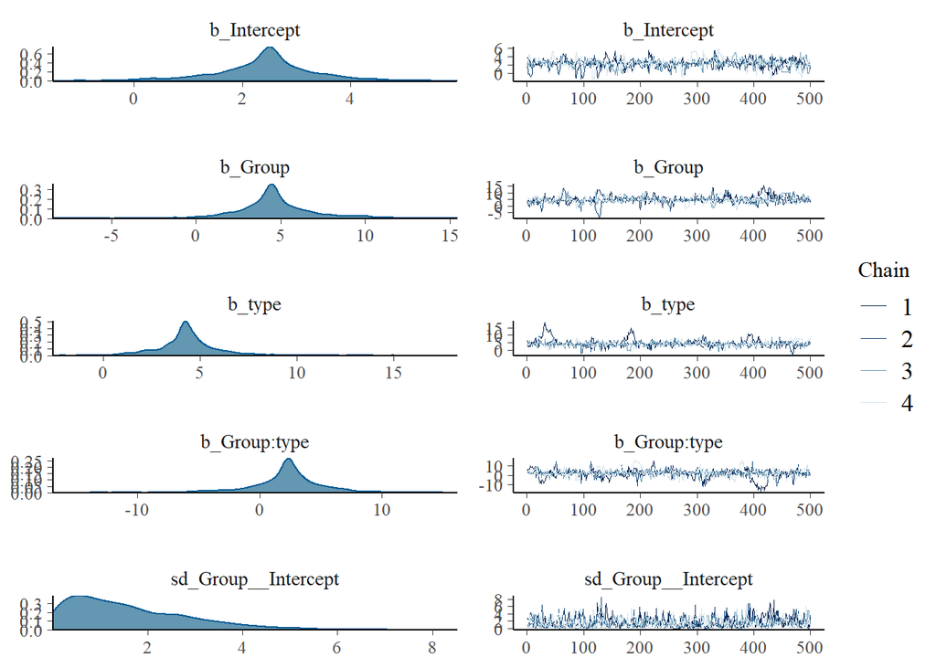

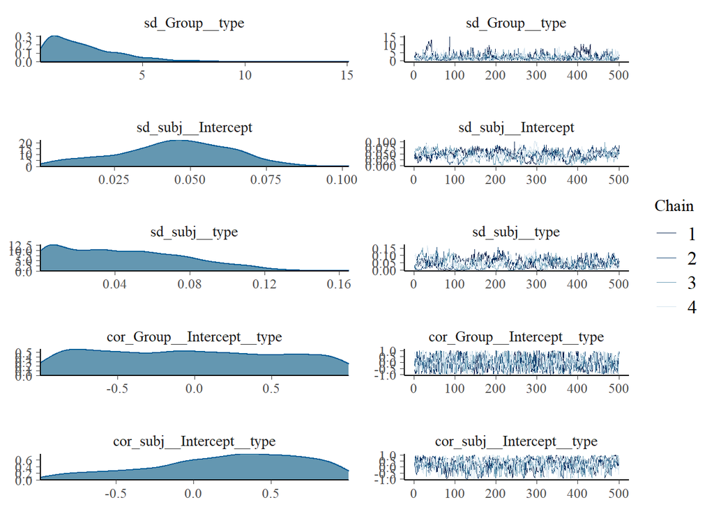

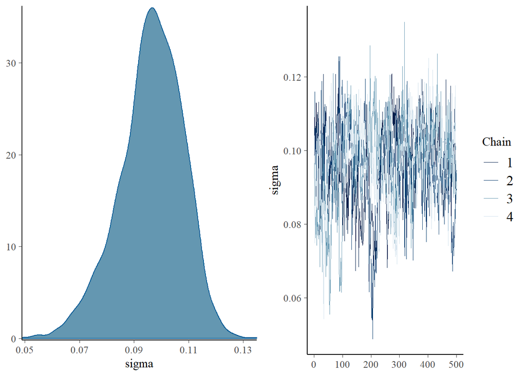

```r
plot(model_4)
```

至此我们已将被试和组别的随机效应也已纳入模型的考量之中。但是哪种模型更加能够揭示自变量与因变量之间的关系呢，我们尚不清楚，接下来还需要进行模型比较。

```r
loo_compare(loo(model_1),loo(model_2),loo(model_3),loo(model_4))
```

```
##         elpd_diff se_diff
## model_3    0.0       0.0
## model_4   -0.1       0.5
## model_2   -0.2       1.5
## model_1 -204.9       8.1
```

# 3 模型拟合效果与真实值比较

在这部分，我们验证一下模型拟合效果，将模型拟合参数与最初设置的参数值之间进行对比。首先比较固定效应中各参数与之前设置的总体参数（真实值）之间的比较。

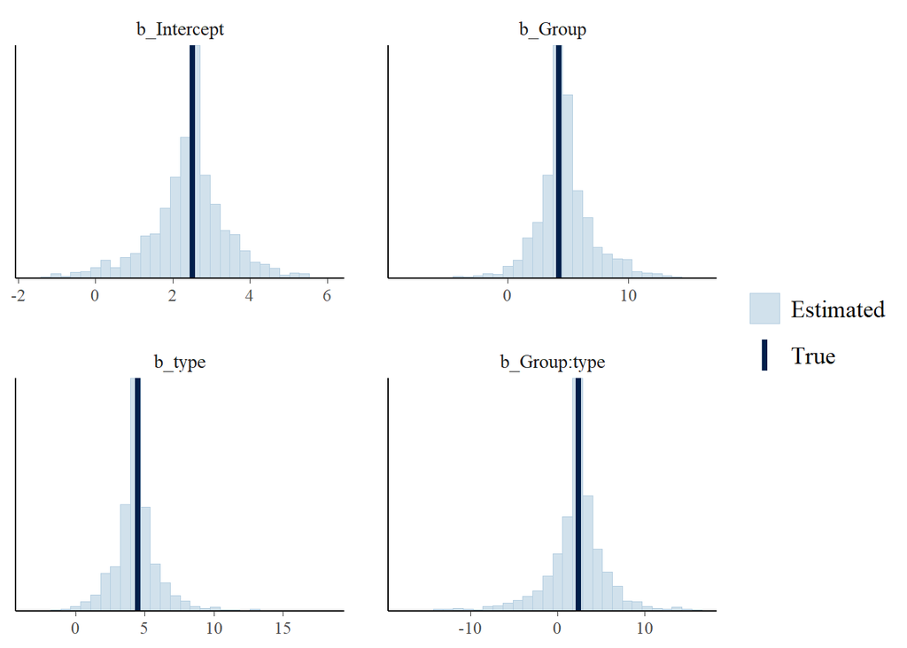

```r
as.data.frame(model_4) %>%
  select(starts_with("b_")) %>%
  mcmc_recover_hist(true = fixed_true)
```

接着比较预设的被试随机效应总体参数(即真实值)和拟合的被试的随机效应的估计参数。

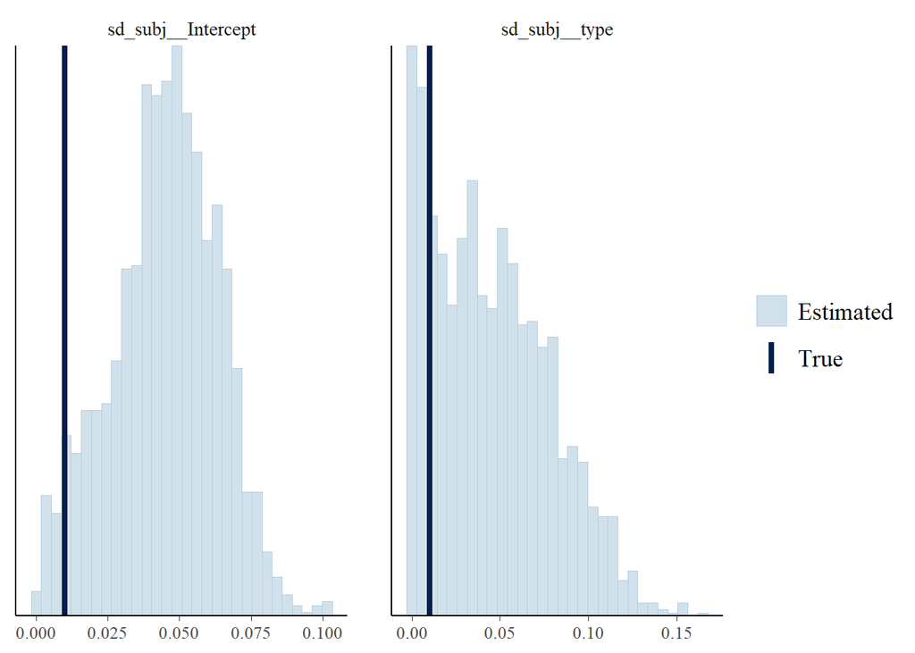

```r
as.data.frame(model_4) %>%
  select(starts_with("sd_subj")) %>%
  mcmc_recover_hist(true = u_sd_subj_true)
```

最后比较预设的组别随机效应总体参数(即真实值)和拟合的组别的随机效应的估计参数。

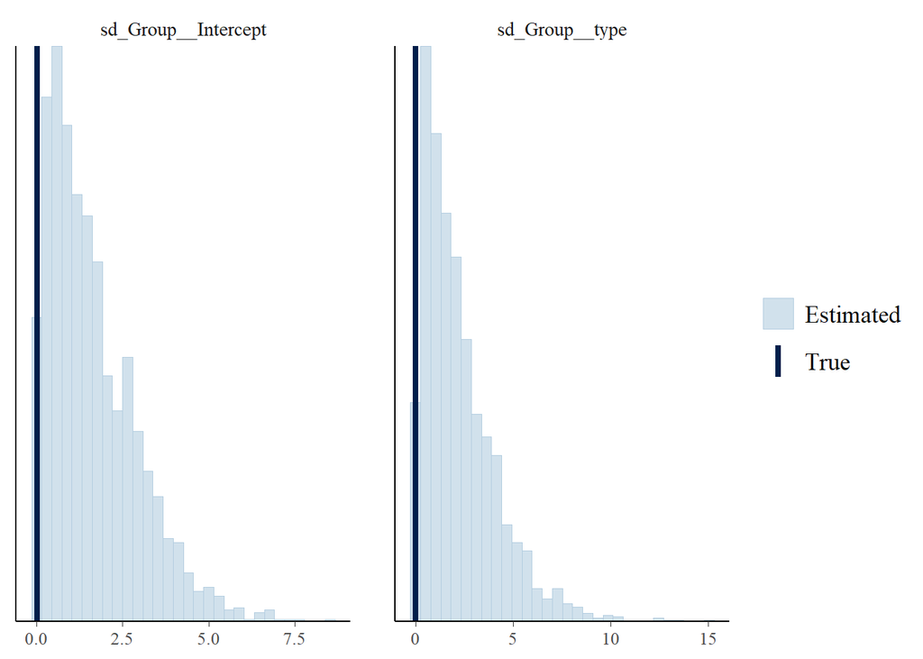

```r
as.data.frame(model_4) %>%
  select(starts_with("sd_Group")) %>%
  mcmc_recover_hist(true = u_sd_Group_true)
```

从以上的图来看，还是比较模型拟合的参数的分布还是包含预设值的/ 至此对于数据建模的步骤以完成差不多。但是对于研究者来说，更重要的还是比较组间差异，两组之间的LPP波幅是否存在显著性的差异。我们可以通过贝叶斯因子（Bayesian factor,BF）对模型拟合的一些参数进行比较 Heck et al. (2022); Schad et al. (2022); Wagenmakers et al. (2010)，从而更好地观察两个组有关自变量因素是否存在差异，这样更能够解释因变量是否存在差异。

# 4 组间差异以及组内差异的比较

研究中通常需要比较组间差异亦或者组内各条件的差异。使用贝叶斯模型进行组间或者组内条件比较时需要注意，在贝叶斯混合线性模型中，一般可以将组间条件和组内条件的参数纳入，从而比较组间因素与组内因素相关的参数。首先我们可以检验差值分布（difference distribution）的95%最高后验密度（highest posterior density）或者置信区间是否包含0进行判断参数在组间或者组内是否有显著性差异。如果0在95%区间之外，即这可以认为存在差异。需要注意的是，在论文写作中我们需要报告各参数的95%置信区间。

```r
library(tidybayes)
```

```r
library(emmeans)
samp1 <- model_4 %>%
  emmeans("Group", by = "type") %>%
  pairs %>%
  gather_emmeans_draws()
samp1 %>%
  median_hdi()
```

```
## # A tibble: 2 x 8
##   contrast                type .value .lower .upper .width .point .interval
##   <fct>                  <dbl>  <dbl>  <dbl>  <dbl>  <dbl> <chr>  <chr>
## 1 (Group-0.5) - Group0.5  -0.5  -3.42  -10.5  2.58    0.95 median hdi
## 2 (Group-0.5) - Group0.5   0.5  -5.72  -11.3  0.455   0.95 median hdi
```

```r
samp1 <- model_4 %>%
  emmeans("type", by = "Group") %>%
  pairs %>%
  gather_emmeans_draws()
samp1 %>%
  median_hdi()
```

```
## # A tibble: 2 x 8
##   contrast             Group .value .lower .upper .width .point .interval
##   <fct>                <dbl>  <dbl>  <dbl>  <dbl>  <dbl> <chr>  <chr>
## 1 (type-0.5) - type0.5  -0.5  -3.08  -9.58  2.22    0.95 median hdi
## 2 (type-0.5) - type0.5   0.5  -5.45 -10.8   0.249   0.95 median hdi
```

虽然比较最高后验密度以及95%d的置信区间，是目前比较推荐采用的方法，但是对于习惯使用p值的研究者们来说，这似乎并不受欢迎。在心理学研究中，许多贝叶斯统计的支持者主张使用贝叶斯因子进行假设检验 Rouder et al. (2018)。在以下的代码中我们将采用贝叶斯因子对组间差异以及组内差异进行检验。可以使用brms的hypothesis函数进行假设检验，并从中提取出贝叶斯因子。

```r
n=hypothesis(model_4,"type<0")
n$Evid.Ratio
```

[output not shown]

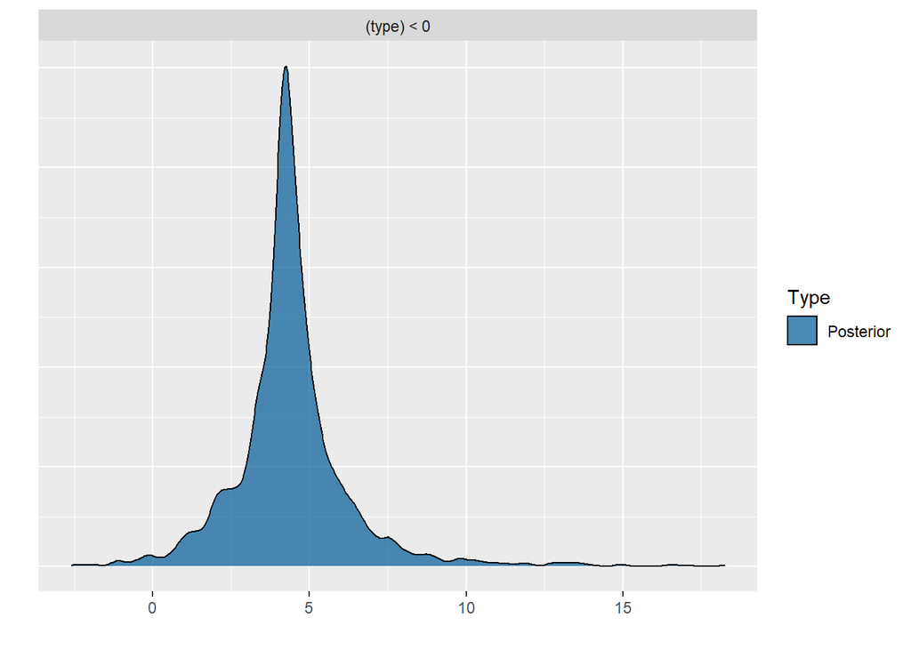

```r
#n
#n$hypothesis
plot(n)
```

```r
#n=hypothesis(model_4,"sd_Group_type<0")
#n
#n$hypothesis$Evid.Ratio
#plot(n)
#难解~~~
```

# 参考文献

Bürkner, P.-C. (n.d.). *Bayesian Distributional Non-Linear Multilevel Modeling with the R Package brms*. 19.

Bürkner, P.-C. (2017). *Advanced Bayesian Multilevel Modeling with the R Package brms* (No. arXiv:1705.11123). arXiv. http://arxiv.org/abs/1705.11123

Heck, D. W., Boehm, U., Böing-Messing, F., Bürkner, P.-C., Derks, K., Dienes, Z., Fu, Q., Gu, X., Karimova, D., Kiers, H. A. L., Klugkist, I., Kuiper, R. M., Lee, M. D., Leenders, R., Leplaa, H. J., Linde, M., Ly, A., Meijerink-Bosman, M., Moerbeek, M., … Hoijtink, H. (2022). A review of applications of the Bayes factor in psychological research. *Psychological Methods*. https://doi.org/gprs76

Rouder, J. N., Haaf, J. M., & Vandekerckhove, J. (2018). Bayesian inference for psychology, part IV: Parameter estimation and Bayes factors. *Psychonomic Bulletin & Review*, *25*(1), 102–113. https://doi.org/gc9qfx

Schad, D. J., Nicenboim, B., Bürkner, P.-C., Betancourt, M., & Vasishth, S. (2022). Workflow techniques for the robust use of bayes factors. *Psychological Methods*. https://doi.org/10.1037/met0000472

Vasishth, S., Nicenboim, B., Beckman, M. E., Li, F., & Kong, E. J. (2018). Bayesian data analysis in the phonetic sciences: A tutorial introduction. *Journal of Phonetics*, *71*, 147–161. https://doi.org/gfzq3c

Wagenmakers, E.-J., Lodewyckx, T., Kuriyal, H., & Grasman, R. (2010). Bayesian hypothesis testing for psychologists: A tutorial on the Savage–Dickey method. *Cognitive Psychology*, *60*(3), 158–189. https://doi.org/10.1016/j.cogpsych.2009.12.001